# R Notebook

Three main parts to Data Wrangling:  
1.Wrangle  
2.Understand  
3.Communicate

Tibble is basically a package that makes a more modern version of R’s original data.frame

```r
library(tidyverse)
```

To use a data frame as a tibble…

```r
as_tibble(iris)
```

| Sepal.Length | Sepal.Width | Petal.Length | Petal.Width | Species |
| --- | --- | --- | --- | --- |
| 5.1 | 3.5 | 1.4 | 0.2 | setosa |
| 4.9 | 3.0 | 1.4 | 0.2 | setosa |
| 4.7 | 3.2 | 1.3 | 0.2 | setosa |
| 4.6 | 3.1 | 1.5 | 0.2 | setosa |
| 5.0 | 3.6 | 1.4 | 0.2 | setosa |
| 5.4 | 3.9 | 1.7 | 0.4 | setosa |
| 4.6 | 3.4 | 1.4 | 0.3 | setosa |
| 5.0 | 3.4 | 1.5 | 0.2 | setosa |
| 4.4 | 2.9 | 1.4 | 0.2 | setosa |
| 4.9 | 3.1 | 1.5 | 0.1 | setosa |

[output cut: 140 more lines]

It’s possible for a tibble to have column names that are not valid R variable names, aka non-syntactic names. For example, they might not start with a letter, or they might contain unusual characters like a space. To refer to these variables, you need to surround them with backticks, :)`

A tribble makes it so functions can be column names

Tibbles have a refined print method that shows only the first 10 rows, and all the columns that fit on screen.

To show more than just 10 rows: First, you can explicitly print() the data frame and control the number of rows (n) and the width of the display. width = Inf will display all columns

To extract a name of a column, df$x To extract a column based on position, df[[1]]

10.5 Exercises

```r
mtcars #you can tell if an object is a tibble because it will say it is a tibble at te top and also because it will only show the first 10 rows.
```

|  | mpg | cyl | disp | hp | drat | wt | qsec | vs | am | gear | carb |
| --- | --- | --- | --- | --- | --- | --- | --- | --- | --- | --- | --- |
| Mazda RX4 | 21.0 | 6 | 160.0 | 110 | 3.90 | 2.620 | 16.46 | 0 | 1 | 4 | 4 |
| Mazda RX4 Wag | 21.0 | 6 | 160.0 | 110 | 3.90 | 2.875 | 17.02 | 0 | 1 | 4 | 4 |
| Datsun 710 | 22.8 | 4 | 108.0 | 93 | 3.85 | 2.320 | 18.61 | 1 | 1 | 4 | 1 |
| Hornet 4 Drive | 21.4 | 6 | 258.0 | 110 | 3.08 | 3.215 | 19.44 | 1 | 0 | 3 | 1 |
| Hornet Sportabout | 18.7 | 8 | 360.0 | 175 | 3.15 | 3.440 | 17.02 | 0 | 0 | 3 | 2 |
| Valiant | 18.1 | 6 | 225.0 | 105 | 2.76 | 3.460 | 20.22 | 1 | 0 | 3 | 1 |
| Duster 360 | 14.3 | 8 | 360.0 | 245 | 3.21 | 3.570 | 15.84 | 0 | 0 | 3 | 4 |
| Merc 240D | 24.4 | 4 | 146.7 | 62 | 3.69 | 3.190 | 20.00 | 1 | 0 | 4 | 2 |
| Merc 230 | 22.8 | 4 | 140.8 | 95 | 3.92 | 3.150 | 22.90 | 1 | 0 | 4 | 2 |
| Merc 280 | 19.2 | 6 | 167.6 | 123 | 3.92 | 3.440 | 18.30 | 1 | 0 | 4 | 4 |

[output cut: 22 more lines]

```r
as_tibble(mtcars)
```

|  | mpg | cyl | disp | hp | drat | wt | qsec | vs | am | gear | carb |
| --- | --- | --- | --- | --- | --- | --- | --- | --- | --- | --- | --- |
| 1 | 21.0 | 6 | 160.0 | 110 | 3.90 | 2.620 | 16.46 | 0 | 1 | 4 | 4 |
| 2 | 21.0 | 6 | 160.0 | 110 | 3.90 | 2.875 | 17.02 | 0 | 1 | 4 | 4 |
| 3 | 22.8 | 4 | 108.0 | 93 | 3.85 | 2.320 | 18.61 | 1 | 1 | 4 | 1 |
| 4 | 21.4 | 6 | 258.0 | 110 | 3.08 | 3.215 | 19.44 | 1 | 0 | 3 | 1 |
| 5 | 18.7 | 8 | 360.0 | 175 | 3.15 | 3.440 | 17.02 | 0 | 0 | 3 | 2 |
| 6 | 18.1 | 6 | 225.0 | 105 | 2.76 | 3.460 | 20.22 | 1 | 0 | 3 | 1 |
| 7 | 14.3 | 8 | 360.0 | 245 | 3.21 | 3.570 | 15.84 | 0 | 0 | 3 | 4 |
| 8 | 24.4 | 4 | 146.7 | 62 | 3.69 | 3.190 | 20.00 | 1 | 0 | 4 | 2 |
| 9 | 22.8 | 4 | 140.8 | 95 | 3.92 | 3.150 | 22.90 | 1 | 0 | 4 | 2 |
| 10 | 19.2 | 6 | 167.6 | 123 | 3.92 | 3.440 | 18.30 | 1 | 0 | 4 | 4 |

[output cut: 22 more lines]

```r
df <- tibble(abc = 1, xyz = "a")
```

```
`list_len()` is deprecated as of rlang 0.2.0.
Please use `new_list()` instead.
```

```r
df$x
```

```
Unknown or uninitialised column: 'x'.
```

```r
df[, "xyz"]
```

| xyz |
| --- |
| a |

```r
df[, c("abc", "xyz")]
```

| abc | xyz |
| --- | --- |
| 1 | a |

```r
practice <- tibble(
  `1` = 1:10,
  `2` = `1` * 2 + 9
)
practice[["1"]]
```

```
 [1]  1  2  3  4  5  6  7  8  9 10
```

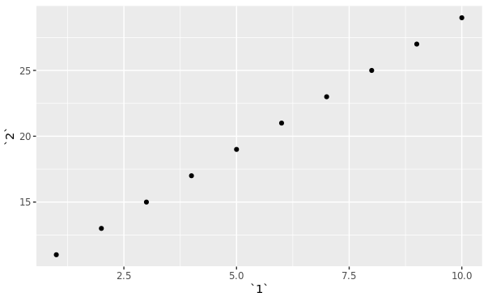

```r
ggplot(practice, aes(x = `1`, y = `2`)) +
  geom_point()
```

```r
mutate(practice, `3` = `2`/`1`)
```

| 1 | 2 | 3 |
| --- | --- | --- |
| 1 | 11 | 11.000000 |
| 2 | 13 | 6.500000 |
| 3 | 15 | 5.000000 |
| 4 | 17 | 4.250000 |
| 5 | 19 | 3.800000 |
| 6 | 21 | 3.500000 |
| 7 | 23 | 3.285714 |
| 8 | 25 | 3.125000 |
| 9 | 27 | 3.000000 |
| 10 | 29 | 2.900000 |

```r
practice <- rename(practice, one = `1`, two = `2`)
```

Chapter 11:

Most of readr’s functions are concerned with turning flat files into data frames:

The first argument to read_csv() is the most important: it’s the path to the file to read.

The data might not have column names. You can use col_names = FALSE to tell read_csv() not to treat the first row as headings, and instead label them sequentially from X1 to Xn

na = “.” replaces any NA values w a .

So in general read_csv is better than raed.csv. It’s faster to read and will reduce common problems w Base R.

“x,y1,‘a,b’” to read this into a data frame you would need to use read_delim() and specify what a comma and a quote is.

parse_*() functions take a character vector and return a more specialised vector like a logical, integer, or date

parse_double() can turn a comma to a decimal mark Ex/

```r
parse_double("1.23")
```

```
[1] 1.23
```

```
#> [1] 1.23
```

```r
parse_double("1,23", locale = locale(decimal_mark = ","))
```

```
[1] 1.23
```

```
#> [1] 1.23
```

parse_number() ignores non-numeric characters before and after the number. Ex/

```r
parse_number("$100")
```

```
[1] 100
```

```
#> [1] 100
```

```r
parse_number("20%")
```

```
[1] 20
```

```
#> [1] 20
```

```r
parse_number("It cost $123.45")
```

```
[1] 123.45
```

[output not shown]

parse_datetime() expects an ISO8601 date-time. ISO8601 is an international standard in which the components of a date are organised from biggest to smallest: year, month, day, hour, minute, second.

Non-digits %. skips one non-digit character. %* skips any number of non-digits.

Exercises: The most important arguments to local are the data and time arguments as well as decimal mark and a grouping argument.

```r
locale(decimal_mark = ".", grouping_mark = ".")
```

```
Error: `decimal_mark` and `grouping_mark` must be different
```

If you set the decimal and group mark arguments to the same character there’s an error. They have to be different. If one is set as comma, the other period and vice versa.

In foreign countries, you can change order of date format:

```r
Spain<- locale(date_format = "%d/%m/%Y")
parse_date("05/03/2019", locale = Spain)
```

```
[1] "2019-03-05"
```

read_csv() uses a common, read_csv2() uses a semicolon

```r
d1 <- "January 1, 2010"
d2 <- "2015-Mar-07"
d3 <- "06-Jun-2017"
d4 <- c("August 19 (2015)", "July 1 (2015)")
d5 <- "12/30/14" # Dec 30, 2014
t1 <- "1705"
t2 <- "11:15:10.12 PM"
```

```r
parse_date(d1, "%B %d, %Y")
```

```
[1] "2010-01-01"
```

```r
parse_date(d2, "%Y-%b-%d")
```

```
[1] "2015-03-07"
```

```r
parse_date(d3, "%d-%b-%Y")
```

```
[1] "2017-06-06"
```